# Self-Driving Car Engineer Nanodegree

### Apply region of interest

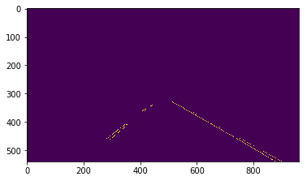

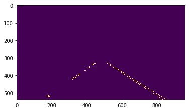

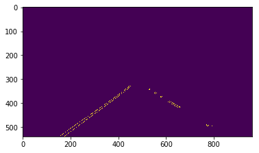

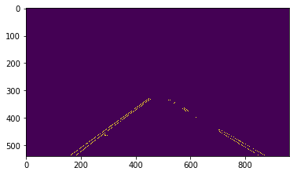

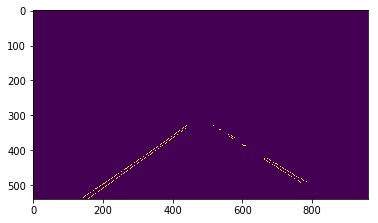

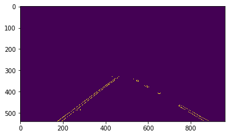

```python
for files in dir_files:
    image = mpimg.imread("test_images/" + files)
    image_gray = grayscale(image)
    image_blur = gaussian_blur(image_gray, kernel_size=11)
    image_canny = canny(image_blur, low_threshold=50, high_threshold=100)
    imshape = image.shape
    vertices = np.array([[(130, imshape[0]), (430, 330), (520, 330), (900, imshape[0])]], dtype=np.int32)
    image_masked = region_of_interest(image_canny, vertices)
    plt.imshow(image_masked)
    plt.show()
```

### Perform Hough transform

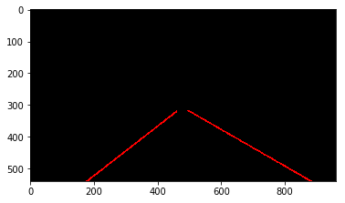

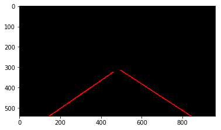

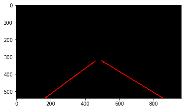

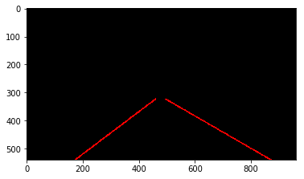

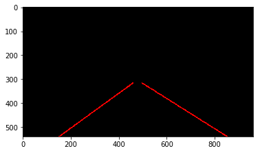

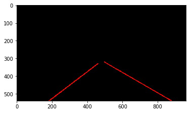

```python
for files in dir_files:
    image = mpimg.imread("test_images/" + files)
    image_gray = grayscale(image)
    image_blur = gaussian_blur(image_gray, kernel_size=11)
    image_canny = canny(image_blur, low_threshold=50, high_threshold=100)
    imshape = image.shape
    vertices = np.array([[(130, imshape[0]), (430, 330), (520, 330), (900, imshape[0])]], dtype=np.int32)
    image_masked = region_of_interest(image_canny, vertices)
    line_imag = hough_lines(image_masked, rho=1, theta=np.pi/180, threshold=30, min_line_len=10, max_line_gap=10)
    plt.imshow(line_imag)
    plt.show()
```

### Original images merged with the lines

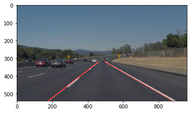

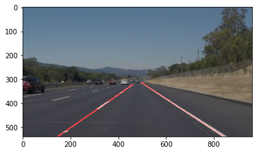

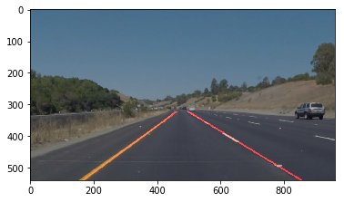

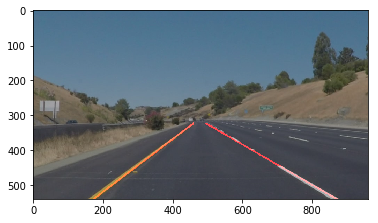

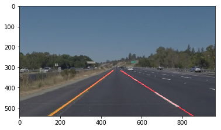

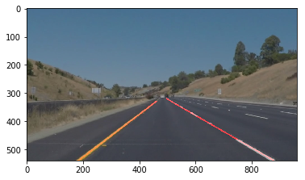

```python
for files in dir_files:
    image = mpimg.imread("test_images/" + files)
    image_gray = grayscale(image)
    image_blur = gaussian_blur(image_gray, kernel_size=11)
    image_canny = canny(image_blur, low_threshold=50, high_threshold=100)
    imshape = image.shape
    vertices = np.array([[(130, imshape[0]), (430, 330), (520, 330), (900, imshape[0])]], dtype=np.int32)
    image_masked = region_of_interest(image_canny, vertices)
    line_imag = hough_lines(image_masked, rho=1, theta=np.pi/180, threshold=30, min_line_len=10, max_line_gap=10)
    final_image = weighted_img(line_imag, image, α=0.7, β=1., γ=1.)
    plt.imshow(final_image)
    plt.savefig('test_images_output/' + files, dpi=300)
    plt.show()
```

## Test on Videos

You know what's cooler than drawing lanes over images? Drawing lanes over video!

We can test our solution on two provided videos:

`solidWhiteRight.mp4`

`solidYellowLeft.mp4`

**Note: if you get an import error when you run the next cell, try changing your kernel (select the Kernel menu above --> Change Kernel). Still have problems? Try relaunching Jupyter Notebook from the terminal prompt. Also, consult the forums for more troubleshooting tips.**

**If you get an error that looks like this:**

```
NeedDownloadError: Need ffmpeg exe.
You can download it by calling:
imageio.plugins.ffmpeg.download()
```

**Follow the instructions in the error message and check out [this forum post](https://discussions.udacity.com/t/project-error-of-test-on-videos/274082) for more troubleshooting tips across operating systems.**

```python
# Import everything needed to edit/save/watch video clips
from moviepy.editor import VideoFileClip
from IPython.display import HTML
```

```python
def process_image(image):
    # NOTE: The output you return should be a color image (3 channel) for processing video below
    # TODO: put your pipeline here,
    # you should return the final output (image where lines are drawn on lanes)
    image_gray = grayscale(image)
    image_blur = gaussian_blur(image_gray, kernel_size=11)
    image_canny = canny(image_blur, low_threshold=50, high_threshold=100)
    imshape = image.shape
    vertices = np.array([[(130, imshape[0]), (430, 330), (520, 330), (900, imshape[0])]], dtype=np.int32)
    image_masked = region_of_interest(image_canny, vertices)
    line_imag = hough_lines(image_masked, rho=1, theta=np.pi/180, threshold=30, min_line_len=10, max_line_gap=10)
    final_image = weighted_img(line_imag, image, α=0.8, β=1., γ=0.)
    return final_image
```

### White line test

```python
white_output = 'test_videos_output/solidWhiteRight.mp4'
## To speed up the testing process you may want to try your pipeline on a shorter subclip of the video
## To do so add .subclip(start_second,end_second) to the end of the line below
## Where start_second and end_second are integer values representing the start and end of the subclip
## You may also uncomment the following line for a subclip of the first 5 seconds
##clip1 = VideoFileClip("test_videos/solidWhiteRight.mp4").subclip(0,5)
clip1 = VideoFileClip("test_videos/solidWhiteRight.mp4")
white_clip = clip1.fl_image(process_image) #NOTE: this function expects color images!!
%time white_clip.write_videofile(white_output, audio=False)
```

```
Moviepy - Building video test_videos_output/solidWhiteRight.mp4.
Moviepy - Writing video test_videos_output/solidWhiteRight.mp4
```

```
Moviepy - Done !
Moviepy - video ready test_videos_output/solidWhiteRight.mp4
Wall time: 10.6 s
```

Play the video inline, or if you prefer find the video in your filesystem (should be in the same directory) and play it in your video player of choice.

```python
HTML("""
<video width="960" height="540" controls>
  <source src="{0}">
</video>
""".format(white_output))
```

[video not shown]

### Yellow line test

```python
yellow_output = 'test_videos_output/solidYellowLeft.mp4'
## To speed up the testing process you may want to try your pipeline on a shorter subclip of the video
## To do so add .subclip(start_second,end_second) to the end of the line below
## Where start_second and end_second are integer values representing the start and end of the subclip
## You may also uncomment the following line for a subclip of the first 5 seconds
##clip2 = VideoFileClip('test_videos/solidYellowLeft.mp4').subclip(0,5)
clip2 = VideoFileClip('test_videos/solidYellowLeft.mp4')
yellow_clip = clip2.fl_image(process_image)
%time yellow_clip.write_videofile(yellow_output, audio=False)
```

```
Moviepy - Building video test_videos_output/solidYellowLeft.mp4.
Moviepy - Writing video test_videos_output/solidYellowLeft.mp4
```

```
Moviepy - Done !
Moviepy - video ready test_videos_output/solidYellowLeft.mp4
Wall time: 30.6 s
```

```python
HTML("""
<video width="960" height="540" controls>
  <source src="{0}">
</video>
""".format(yellow_output))
```

[video not shown]

## Writeup and Submission

If you're satisfied with your video outputs, it's time to make the report writeup in a pdf or markdown file. Once you have this Ipython notebook ready along with the writeup, it's time to submit for review! Here is a [link](https://github.com/udacity/CarND-LaneLines-P1/blob/master/writeup_template.md) to the writeup template file.

## Optional Challenge (not done..)

Try your lane finding pipeline on the video below. Does it still work? Can you figure out a way to make it more robust? If you're up for the challenge, modify your pipeline so it works with this video and submit it along with the rest of your project!

```python
challenge_output = 'test_videos_output/challenge.mp4'
## To speed up the testing process you may want to try your pipeline on a shorter subclip of the video
## To do so add .subclip(start_second,end_second) to the end of the line below
## Where start_second and end_second are integer values representing the start and end of the subclip
## You may also uncomment the following line for a subclip of the first 5 seconds
##clip3 = VideoFileClip('test_videos/challenge.mp4').subclip(0,5)
clip3 = VideoFileClip('test_videos/challenge.mp4')
challenge_clip = clip3.fl_image(process_image)
%time challenge_clip.write_videofile(challenge_output, audio=False)
```

```python
HTML("""
<video width="960" height="540" controls>
  <source src="{0}">
</video>
""".format(challenge_output))
```